# Strukturna bliskost dezinformacijskim ekosustavu: Narativni profili hrvatskih medija (2021.–2026.)

# 2 Teorijski okvir

## 2.1 Dezinformacija kao strukturno obilježje ekosustava

(**benkler2018network?**) u svojoj utjecajnoj studiji američkog medijskog prostora pokazuju da je dezinformacija manje pitanje pojedinačnih lažnih tvrdnji, a više pitanje strukturne asimetrije medijskog ekosustava. Desni medijski prostor u SAD-u karakterizira zatvoreni narativni sustav u kojem se isti okviri (institucionalno nepovjerenje, medijska kritika, konstrukcija vanjskih prijetnji) cirkularno pojačavaju, dok lijevi medijski prostor pokazuje veću narativnu raznolikost i veće oslanjanje na etablirane izvore.

(**freelon2020false?**) proširuju ovu perspektivu argumentirajući da je dezinformacija inherentno politički komunikacijski fenomen koji se ne može razumjeti izvan konteksta narativnih strategija kojima politički akteri oblikuju javni diskurs. Njihov pristup sugerira da je produktivniji analitički fokus na strukturne obrasce narativa nego na istinitost pojedinačnih tvrdnji.

(**hameleers2022framing?**) nudi integrativni okvir koji povezuje aktere, namjere i tehnike dezinformacijskog diskursa. Za naše istraživanje posebno je relevantan uvid da isti narativni okvir (npr. institucionalno nepovjerenje) može biti legitimna demokratska kritika ili element dezinformacijskog ekosustava, ovisno o strukturnom kontekstu u kojem se pojavljuje.

## 2.2 Od binarne klasifikacije prema kontinuumu

Ključna metodološka inovacija ovog rada jest pomak od binarne klasifikacije (dezinformacija da/ne) prema mjerenju na kontinuumu strukturne bliskosti. Sličan pristup koriste (**vanatteveldt2021validity?**) u kontekstu analize sentimenta, gdje pokazuju da su kontinuirane mjere informativnije od kategorijalnih. Naš Narrative Proximity Index (NPI) konceptualizira strukturnu bliskost s dezinformacijskim ekosustavu kao kompozitnu mjeru koja integrira više narativnih obilježja u jedinstveni skor.

# 3 Podaci i metode

## 3.1 Korpus i klasifikacija

Koristimo isti korpus i klasifikaciju medijskih izvora opisanu u pratećem radu o narativnom uokvirivanju. Ukratko, korpus sadrži 443,138 web članaka iz razdoblja 2021-01-01 do 2026-01-06, klasificiranih u sedam tipova medija. Osam narativnih okvira detektirano je rječničkom metodom.

## 3.2 Konstrukcija Narrative Proximity Indexa (NPI)

NPI je kompozitni indeks koji integrira narativne okvire za koje postoji teorijsko utemeljenje da su strukturno bliski dezinformacijskim ekosustavu. Indeks ne uključuje sve okvire jer nisu svi relevantni za dezinformacijske narativne strukture. Okviri TRADITIONAL_VALUES i FAITH_DEFENCE, primjerice, odražavaju religijski identitet medija ali nemaju inherentnu vezu s dezinformacijskim narativima.

Indeks uključuje četiri okvira s teorijski utemeljenim težinama:

- **CONSPIRACY** (težina 2.0). Konspirativni okvir je najprepoznatljivije obilježje dezinformacijskih narativa (Wardle and Derakhshan 2017). Premaeksponiran je u dezinformacijskim ekosustavu u usporedbi s etabliranim medijskim sustavima (**benkler2018network?**).
- **FOREIGN_THREAT** (težina 1.5). Konstrukcija vanjskih prijetnji služi kao mehanizam delegitimizacije alternativnih perspektiva pripisivanjem stranog utjecaja (Wodak 2015).
- **INSTITUTIONAL_DISTRUST** (težina 1.5). Sustavno nepovjerenje prema institucijama potkopava autoritet etabliranih izvora informacija, što je preduvjet za prihvaćanje alternativnih narativa (**freelon2020false?**).
- **MEDIA_CRITIQUE** (težina 1.0). Kritika mainstream medija kao pristranih ili cenzorskih delegitimizira tradicionalne gatekeepere informacija (**benkler2018network?**).

Formalno, za članak $i$:

$$\text{NPI}_i^{(w)} = w_1 \cdot C_i + w_2 \cdot F_i + w_3 \cdot D_i + w_4 \cdot M_i$$

gdje su $C$, $F$, $D$, $M$ binarni indikatori za CONSPIRACY, FOREIGN_THREAT, INSTITUTIONAL_DISTRUST i MEDIA_CRITIQUE, a $w = (w_1, w_2, w_3, w_4)$ vektor težina. Osnovna specifikacija koristi $w = (2, 1.5, 1.5, 1)$.

NPI se potom normalizira na raspon 0 do 100 unutar korpusa.

## 3.3 Strategija robusnosti

Kritička slabost svakog kompozitnog indeksa jest arbitrarnost težina (**saltelli2002sensitivity?**). Da bismo pokazali da naši nalazi ne ovise o specifičnom odabiru težina, testiramo pet alternativnih specifikacija:

1. **Osnovna** (baseline): $w = (2, 1.5, 1.5, 1)$
2. **Jednake težine** (equal): $w = (1, 1, 1, 1)$
3. **Samo zavjera** (conspiracy only): $w = (1, 0, 0, 0)$
4. **Bez medijske kritike** (no media): $w = (2, 1.5, 1.5, 0)$
5. **Ekstremna** (extreme): $w = (3, 1, 1, 1)$

Ako rangiranje medijskih tipova po prosječnom NPI ostaje stabilno kroz sve specifikacije, zaključujemo da su rezultati robusni.

## 3.4 Mrežna analiza okvira

Za identifikaciju narativnih klastera koristimo mrežnu analizu supojavljivanja okvira. Konstruiramo graf u kojem su čvorovi okviri, a težina brida odgovara učestalosti zajedničkog pojavljivanja dvaju okvira u istom članku. Zasebno konstruiramo grafove za svaki tip medija i uspoređujemo njihovu strukturu pomoću hijerarhijskog klasteriranja profilnih vektora medijskih tipova.

## 3.5 Analiza osjetljivosti na klasifikacijsku granicu

Portali poput narod.hr i dnevno.hr klasificirani su kao “Catholic Aligned” na temelju istraživačke procjene. Ova klasifikacija je analitički posljedična jer utječe na prosječni NPI katoličke kategorije. Provodimo analizu osjetljivosti u kojoj iste portale reklasificiramo kao “Conservative” i promatramo kako se rezultati mijenjaju.

# 4 Rezultati

## 4.1 NPI po tipu medija (IP1)

```r
# Baseline NPI is already in the data as disinfo_alignment_norm
# Compute alternative weightings

compute_npi <- function(data, w, label) {
  raw <- w[1] * data$frame_CONSPIRACY +
         w[2] * data$frame_FOREIGN_THREAT +
         w[3] * data$frame_INSTITUTIONAL_DISTRUST +
         w[4] * data$frame_MEDIA_CRITIQUE
  # Normalize 0 to 100
  rng <- max(raw, na.rm = TRUE) - min(raw, na.rm = TRUE)
  if (rng == 0) rng <- 1
  norm <- (raw - min(raw, na.rm = TRUE)) / rng * 100
  tibble(npi = norm, spec = label)
}

specs <- list(
  list(w = c(2, 1.5, 1.5, 1),   label = "Osnovna (2, 1.5, 1.5, 1)"),
  list(w = c(1, 1, 1, 1),       label = "Jednake (1, 1, 1, 1)"),
  list(w = c(1, 0, 0, 0),       label = "Samo zavjera (1, 0, 0, 0)"),
  list(w = c(2, 1.5, 1.5, 0),   label = "Bez medij. kritike (2, 1.5, 1.5, 0)"),
  list(w = c(3, 1, 1, 1),       label = "Ekstremna (3, 1, 1, 1)")
)

# Add all NPI variants to full corpus
for (sp in specs) {
  col_name <- paste0("npi_", gsub("[^a-z]", "", tolower(sp$label)))
  npi_vals <- compute_npi(full_corpus, sp$w, sp$label)
  full_corpus[[col_name]] <- npi_vals$npi
}

npi_variant_cols <- grep("^npi_", names(full_corpus), value = TRUE)
```

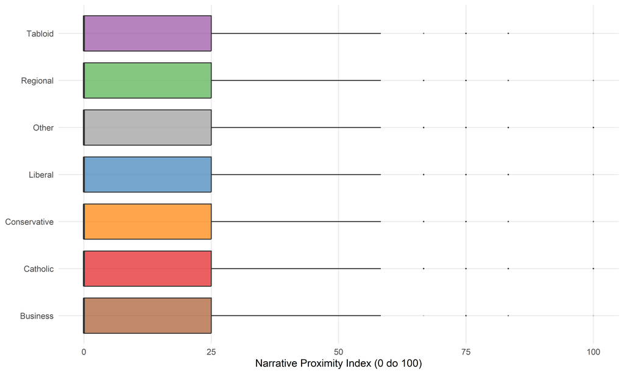

Figure 1: Slika 1. Distribucija NPI (osnovna specifikacija) po tipu medija

```r
ggplot(full_corpus, aes(x = reorder(media_type, disinfo_alignment_norm, FUN = median),
                        y = disinfo_alignment_norm, fill = media_type)) +
  geom_boxplot(alpha = 0.7, outlier.size = 0.3, outlier.alpha = 0.15) +
  scale_fill_manual(values = media_colors, guide = "none") +
  labs(
    x = NULL,
    y = "Narrative Proximity Index (0 do 100)"
  ) +
  coord_flip()
```

```r
npi_summary <- full_corpus |>
  group_by(media_type) |>
  summarise(
    N = n(),
    Prosjek = round(mean(disinfo_alignment_norm, na.rm = TRUE), 1),
    Medijan = round(median(disinfo_alignment_norm, na.rm = TRUE), 1),
    SD = round(sd(disinfo_alignment_norm, na.rm = TRUE), 1),
    Q75 = round(quantile(disinfo_alignment_norm, 0.75, na.rm = TRUE), 1),
    Q90 = round(quantile(disinfo_alignment_norm, 0.90, na.rm = TRUE), 1),
    `Pct > 50` = round(mean(disinfo_alignment_norm > 50, na.rm = TRUE) * 100, 2),
    .groups = "drop"
  ) |>
  arrange(desc(Prosjek))

kable(npi_summary, format.args = list(big.mark = ",")) |>
  kable_styling(bootstrap_options = c("striped", "hover"), full_width = FALSE)
```

Table 1: Tablica 1. Sumarne statistike NPI po tipu medija (osnovna specifikacija)

| media_type | N | Prosjek | Medijan | SD | Q75 | Q90 | Pct > 50 |
| --- | --- | --- | --- | --- | --- | --- | --- |
| Business | 1,196 | 13.6 | 0 | 17.7 | 25 | 33.3 | 4.68 |
| Other | 256,216 | 9.2 | 0 | 15.1 | 25 | 25.0 | 2.40 |
| Conservative | 18,516 | 8.7 | 0 | 14.3 | 25 | 25.0 | 1.89 |
| Tabloid | 20,720 | 8.7 | 0 | 14.2 | 25 | 25.0 | 1.90 |
| Catholic | 92,915 | 8.6 | 0 | 13.2 | 25 | 25.0 | 1.03 |
| Liberal | 28,160 | 8.2 | 0 | 14.3 | 25 | 25.0 | 2.08 |
| Regional | 25,415 | 8.0 | 0 | 13.5 | 25 | 25.0 | 1.50 |

Stupac “Pct > 50” pokazuje koji postotak članaka u svakom tipu medija prelazi srednju vrijednost indeksa. Ovo je informativnije od prosjeka jer distribucija NPI je izrazito desno asimetrična (većina članaka ima NPI = 0).

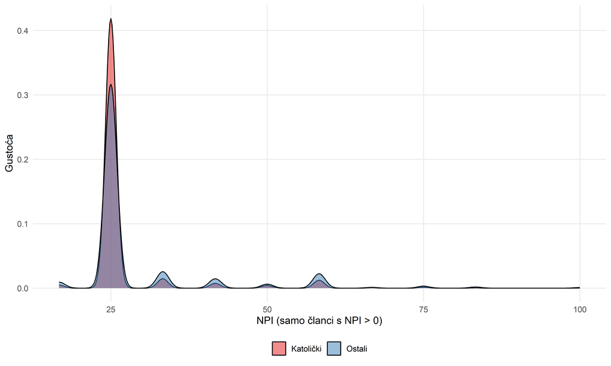

Figure 2: Slika 2. Gustoća distribucije NPI za katoličke vs. ostale medije (samo članci s NPI > 0)

```r
npi_positive <- full_corpus |>
  filter(disinfo_alignment_norm > 0) |>
  mutate(group = ifelse(media_type == "Catholic", "Katolički", "Ostali"))

if (nrow(npi_positive) > 0) {
  ggplot(npi_positive, aes(x = disinfo_alignment_norm, fill = group)) +
    geom_density(alpha = 0.5) +
    scale_fill_manual(values = c("Katolički" = "#e41a1c", "Ostali" = "#377eb8")) +
    labs(
      x = "NPI (samo članci s NPI > 0)",
      y = "Gustoća",
      fill = NULL
    )
}
```

```r
kw <- kruskal.test(disinfo_alignment_norm ~ media_type, data = full_corpus)

cat("Kruskal-Wallis test: NPI ~ tip medija\n")
```

```
Kruskal-Wallis test: NPI ~ tip medija
```

```r
cat("Chi-squared:", round(kw$statistic, 2), "\n")
```

```
Chi-squared: 330.07
```

```r
cat("df:", kw$parameter, "\n")
```

```
df: 6
```

```r
cat("p:", formatC(kw$p.value, format = "e", digits = 3), "\n\n")
```

```
p: 2.926e-68
```

```r
# Pairwise Wilcoxon with BH correction
pw <- pairwise.wilcox.test(
  full_corpus$disinfo_alignment_norm,
  full_corpus$media_type,
  p.adjust.method = "BH"
)

pw_df <- as.data.frame(pw$p.value)
pw_df$media_1 <- rownames(pw_df)

pw_long <- pw_df |>
  pivot_longer(cols = -media_1, names_to = "media_2", values_to = "p_adj") |>
  filter(!is.na(p_adj)) |>
  filter(media_1 == "Catholic" | media_2 == "Catholic") |>
  mutate(p_display = ifelse(p_adj < 0.001, "< 0.001", sprintf("%.4f", p_adj))) |>
  arrange(p_adj)

kable(pw_long |> select(media_1, media_2, p_display),
      col.names = c("Medij 1", "Medij 2", "p (BH korigirano)")) |>
  kable_styling(bootstrap_options = c("striped", "hover"), full_width = FALSE)
```

Table 2: Tablica 2. Kruskal-Wallis test i post-hoc usporedbe za NPI

| Medij 1 | Medij 2 | p (BH korigirano) |
| --- | --- | --- |
| Catholic | Business | < 0.001 |
| Liberal | Catholic | < 0.001 |
| Regional | Catholic | < 0.001 |
| Other | Catholic | 0.0150 |
| Conservative | Catholic | 0.0428 |
| Tabloid | Catholic | 0.1023 |

### 4.1.1 NPI unutar katoličkih potkategorija

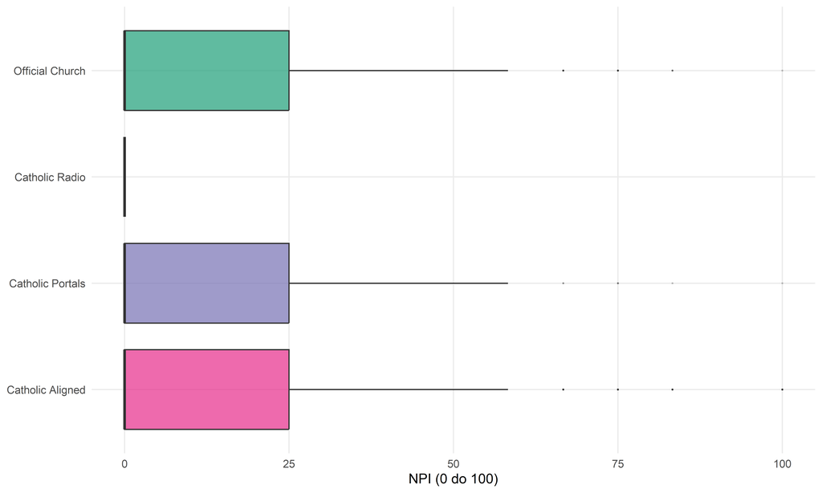

Figure 3: Slika 3. NPI po potkategoriji katoličkih medija

```r
if (n_distinct(catholic_corpus$catholic_subcategory) > 1) {
  ggplot(catholic_corpus,
         aes(x = reorder(catholic_subcategory, disinfo_alignment_norm, FUN = median),
             y = disinfo_alignment_norm, fill = catholic_subcategory)) +
    geom_boxplot(alpha = 0.7, outlier.size = 0.3, outlier.alpha = 0.2) +
    scale_fill_manual(values = catholic_sub_colors, guide = "none") +
    coord_flip() +
    labs(x = NULL, y = "NPI (0 do 100)")
}
```

```r
if (n_distinct(catholic_corpus$catholic_subcategory) > 1) {
  cath_npi <- catholic_corpus |>
    group_by(catholic_subcategory) |>
    summarise(
      N = n(),
      Prosjek = round(mean(disinfo_alignment_norm, na.rm = TRUE), 1),
      Medijan = round(median(disinfo_alignment_norm, na.rm = TRUE), 1),
      SD = round(sd(disinfo_alignment_norm, na.rm = TRUE), 1),
      `Pct > 50` = round(mean(disinfo_alignment_norm > 50, na.rm = TRUE) * 100, 2),
      .groups = "drop"
    ) |>
    arrange(desc(Prosjek))

  kable(cath_npi, format.args = list(big.mark = ",")) |>
    kable_styling(bootstrap_options = c("striped", "hover"), full_width = FALSE)
}
```

Table 3: Tablica 3. NPI po potkategoriji katoličkih medija

| catholic_subcategory | N | Prosjek | Medijan | SD | Pct > 50 |
| --- | --- | --- | --- | --- | --- |
| Catholic Aligned | 18,577 | 11.2 | 0 | 16.0 | 2.97 |
| Official Church | 64,391 | 7.9 | 0 | 12.3 | 0.56 |
| Catholic Portals | 9,943 | 7.6 | 0 | 12.1 | 0.44 |
| Catholic Radio | 4 | 0.0 | 0 | 0.0 | 0.00 |

Očekujemo da će Catholic Aligned portali imati značajno viši NPI od Official Church medija. Ako je to slučaj, prosječni NPI za cjelokupnu kategoriju “Catholic” je pod snažnim utjecajem Catholic Aligned podgrupe. Ovo je ključno za IP4.

## 4.2 Robusnost na alternativne specifikacije (IP2)

```r
# For each NPI variant, compute mean by media type and rank
robustness_data <- lapply(seq_along(specs), function(i) {
  sp <- specs[[i]]
  npi_vals <- compute_npi(full_corpus, sp$w, sp$label)

  full_corpus |>
    mutate(npi_val = npi_vals$npi) |>
    group_by(media_type) |>
    summarise(mean_npi = mean(npi_val, na.rm = TRUE), .groups = "drop") |>
    arrange(desc(mean_npi)) |>
    mutate(
      rank = row_number(),
      spec = sp$label
    )
}) |>
  bind_rows()
```

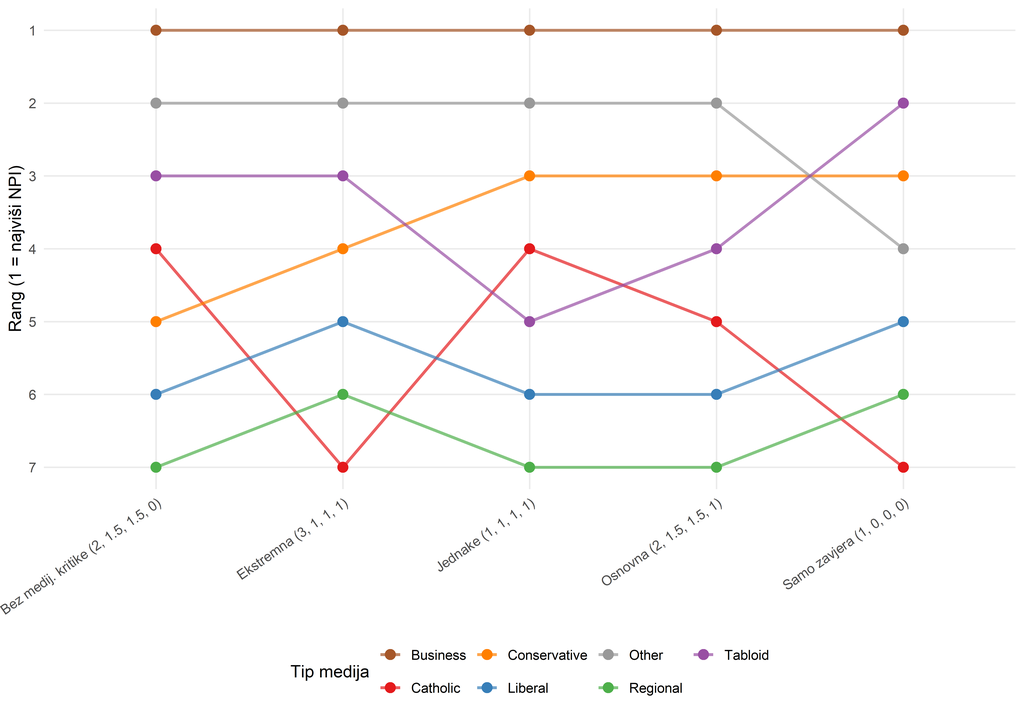

Figure 4: Slika 4. Rang medijskih tipova po prosječnom NPI kroz pet specifikacija težina. Stabilan rang ukazuje na robusnost.

```r
ggplot(robustness_data, aes(x = spec, y = rank, group = media_type, color = media_type)) +
  geom_line(linewidth = 1, alpha = 0.7) +
  geom_point(size = 3) +
  scale_y_reverse(breaks = 1:7) +
  scale_color_manual(values = media_colors) +
  labs(
    x = NULL,
    y = "Rang (1 = najviši NPI)",
    color = "Tip medija"
  ) +
  theme(axis.text.x = element_text(angle = 35, hjust = 1))
```

Ako linije ostaju relativno ravne (isti rang kroz specifikacije), rezultati su robusni. Ako se linije križaju, rangiranje ovisi o odabiru težina i treba ga tumačiti s oprezom.

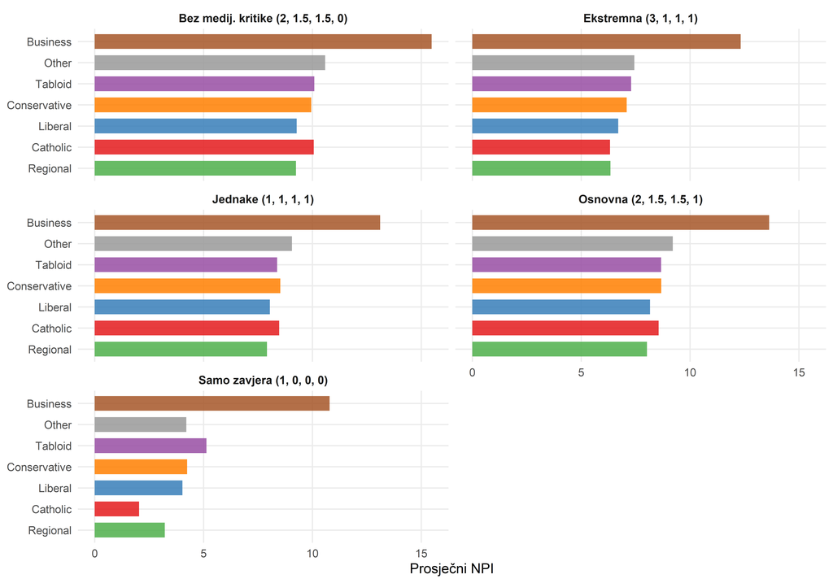

Figure 5: Slika 5. Prosječni NPI po tipu medija za svaku specifikaciju težina

```r
ggplot(robustness_data, aes(x = reorder(media_type, mean_npi), y = mean_npi,
                            fill = media_type)) +
  geom_col(alpha = 0.85, width = 0.7) +
  coord_flip() +
  facet_wrap(~spec, ncol = 2) +
  scale_fill_manual(values = media_colors, guide = "none") +
  labs(x = NULL, y = "Prosječni NPI")
```

```r
# Compute Spearman correlation of ranks between all pairs of specifications
rank_wide <- robustness_data |>
  select(media_type, rank, spec) |>
  pivot_wider(names_from = spec, values_from = rank)

rank_mat <- rank_wide |> select(-media_type) |> as.matrix()
rownames(rank_mat) <- rank_wide$media_type

spec_cor <- cor(rank_mat, method = "spearman")

cor_df <- as.data.frame(round(spec_cor, 3))
cor_df$Specifikacija <- rownames(cor_df)
cor_df <- cor_df |> select(Specifikacija, everything())

kable(cor_df) |>
  kable_styling(bootstrap_options = c("striped", "hover"), full_width = FALSE, font_size = 10)
```

Table 4: Tablica 4. Korelacijski koeficijenti (Spearman) između NPI specifikacija na razini medijskog tipa

|  | Specifikacija | Osnovna (2, 1.5, 1.5, 1) | Jednake (1, 1, 1, 1) | Samo zavjera (1, 0, 0, 0) | Bez medij. kritike (2, 1.5, 1.5, 0) | Ekstremna (3, 1, 1, 1) |
| --- | --- | --- | --- | --- | --- | --- |
| Osnovna (2, 1.5, 1.5, 1) | Osnovna (2, 1.5, 1.5, 1) | 1.000 | 0.964 | 0.750 | 0.893 | 0.857 |
| Jednake (1, 1, 1, 1) | Jednake (1, 1, 1, 1) | 0.964 | 1.000 | 0.571 | 0.857 | 0.714 |
| Samo zavjera (1, 0, 0, 0) | Samo zavjera (1, 0, 0, 0) | 0.750 | 0.571 | 1.000 | 0.643 | 0.893 |
| Bez medij. kritike (2, 1.5, 1.5, 0) | Bez medij. kritike (2, 1.5, 1.5, 0) | 0.893 | 0.857 | 0.643 | 1.000 | 0.786 |
| Ekstremna (3, 1, 1, 1) | Ekstremna (3, 1, 1, 1) | 0.857 | 0.714 | 0.893 | 0.786 | 1.000 |

Spearman korelacije rangova pokazuju stupanj slaganja među specifikacijama. Korelacija blizu 1 znači da različite težinske sheme proizvode isti poredak medijskih tipova.

```r
cath_robustness <- robustness_data |>
  filter(media_type == "Catholic") |>
  select(spec, mean_npi, rank) |>
  mutate(mean_npi = round(mean_npi, 2))

kable(cath_robustness,
      col.names = c("Specifikacija", "Prosječni NPI", "Rang")) |>
  kable_styling(bootstrap_options = c("striped", "hover"), full_width = FALSE)
```

Table 5: Tablica 5. Prosječni NPI za katoličke medije kroz sve specifikacije

| Specifikacija | Prosječni NPI | Rang |
| --- | --- | --- |
| Osnovna (2, 1.5, 1.5, 1) | 8.56 | 5 |
| Jednake (1, 1, 1, 1) | 8.48 | 4 |
| Samo zavjera (1, 0, 0, 0) | 2.04 | 7 |
| Bez medij. kritike (2, 1.5, 1.5, 0) | 10.06 | 4 |
| Ekstremna (3, 1, 1, 1) | 6.33 | 7 |

## 4.3 Narativni klasteri: mrežna analiza (IP3)

Da bismo identificirali skupove okvira koji čine koherentne narativne “pakete”, konstruiramo mrežu supojavljivanja okvira zasebno za svaki tip medija i uspoređujemo njihove strukture.

### 4.3.1 Mrežni graf supojavljivanja

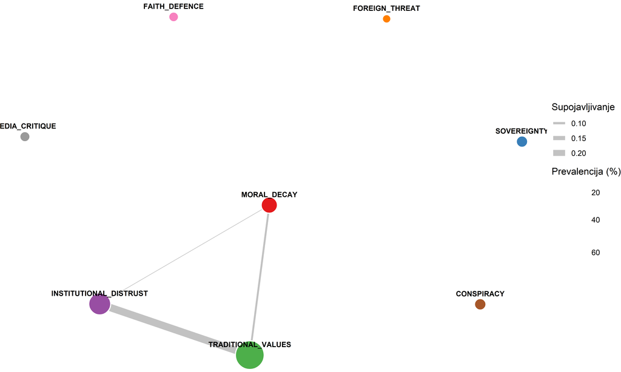

Figure 6: Slika 6. Mreža supojavljivanja okvira u katoličkim medijima. Debljina brida odražava učestalost zajedničkog pojavljivanja. Veličina čvora odražava ukupnu zastupljenost okvira.

```r
build_frame_network <- function(data, min_weight = 0.05) {
  mat <- data |> select(all_of(frame_cols)) |> as.matrix()
  colnames(mat) <- frame_names

  co <- crossprod(mat)
  # Normalize by total articles
  co_norm <- co / nrow(data)
  diag(co_norm) <- 0

  # Filter weak edges
  co_norm[co_norm < min_weight] <- 0

  g <- graph_from_adjacency_matrix(co_norm, mode = "undirected", weighted = TRUE, diag = FALSE)

  # Node size = frame prevalence
  node_prev <- colSums(mat) / nrow(data) * 100
  V(g)$prevalence <- node_prev[V(g)$name]

  g
}

if (nrow(catholic_corpus) > 50) {
  g_cath <- build_frame_network(catholic_corpus)

  # Layout
  set.seed(42)
  layout_coords <- layout_with_fr(g_cath)

  # Convert to data frames for ggplot
  edge_df <- as_data_frame(g_cath, what = "edges")
  node_df <- data.frame(
    name = V(g_cath)$name,
    prevalence = V(g_cath)$prevalence,
    x = layout_coords[, 1],
    y = layout_coords[, 2]
  )

  edge_plot_df <- edge_df |>
    left_join(node_df |> select(name, x, y), by = c("from" = "name")) |>
    rename(x_from = x, y_from = y) |>
    left_join(node_df |> select(name, x, y), by = c("to" = "name")) |>
    rename(x_to = x, y_to = y)

  ggplot() +
    geom_segment(data = edge_plot_df,
                 aes(x = x_from, y = y_from, xend = x_to, yend = y_to, linewidth = weight),
                 alpha = 0.4, color = "gray40") +
    geom_point(data = node_df, aes(x = x, y = y, size = prevalence, fill = name),
               shape = 21, color = "white", stroke = 1) +
    geom_text(data = node_df, aes(x = x, y = y, label = name),
              size = 3, vjust = -1.5, fontface = "bold") +
    scale_fill_manual(values = frame_colors, guide = "none") +
    scale_size_continuous(range = c(4, 15), name = "Prevalencija (%)") +
    scale_linewidth_continuous(range = c(0.3, 4), name = "Supojavljivanje") +
    theme_void() +
    theme(legend.position = "right")
}
```

### 4.3.2 Hijerarhijsko klasteriranje medijskih tipova po narativnom profilu

Umjesto da subjektivno uspoređujemo mreže, koristimo hijerarhijsko klasteriranje na profilnim vektorima. Svaki tip medija opisan je osmodimenzionalnim vektorom (postotak članaka koji aktivira svaki od osam okvira). Euklidska udaljenost i Wardova metoda grupiraju medije s najsličnijim narativnim profilima.

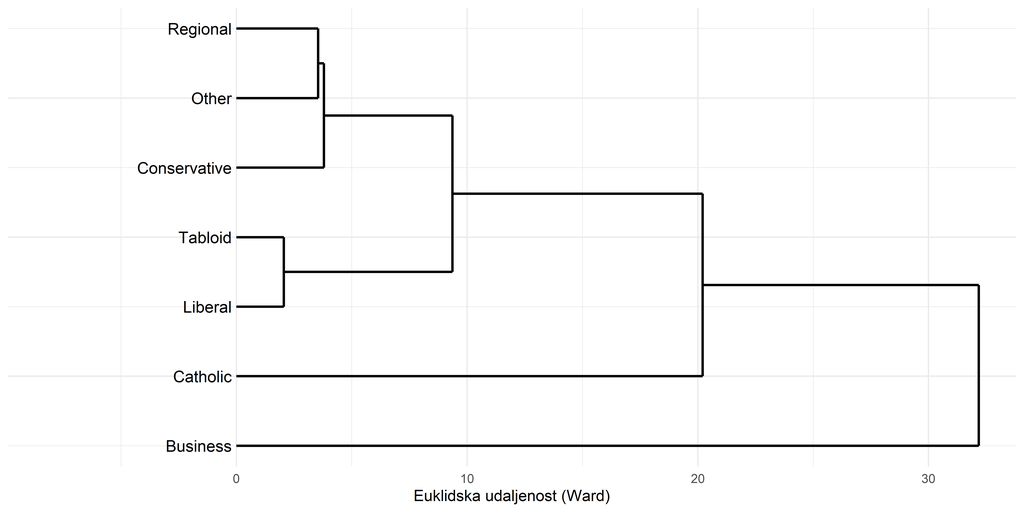

Figure 7: Slika 7. Dendrogram medijskih tipova na temelju narativnih profila. Mediji koji se spajaju na nižoj razini imaju sličnije narativne profile.

```r
profile_data <- full_corpus |>
  group_by(media_type) |>
  summarise(across(all_of(frame_cols), ~mean(.x, na.rm = TRUE) * 100), .groups = "drop")

profile_mat <- as.matrix(profile_data |> select(-media_type))
rownames(profile_mat) <- profile_data$media_type

dist_mat <- dist(profile_mat, method = "euclidean")
hc <- hclust(dist_mat, method = "ward.D2")

dend_data <- dendro_data(hc)

ggplot() +
  geom_segment(data = segment(dend_data),
               aes(x = x, y = y, xend = xend, yend = yend),
               linewidth = 0.8) +
  geom_text(data = label(dend_data),
            aes(x = x, y = y, label = label),
            hjust = 1, size = 4, nudge_y = -0.2) +
  coord_flip() +
  scale_y_continuous(expand = expansion(mult = c(0.3, 0.05))) +
  labs(x = NULL, y = "Euklidska udaljenost (Ward)") +
  theme_minimal() +
  theme(axis.text.y = element_blank(), axis.ticks.y = element_blank())
```

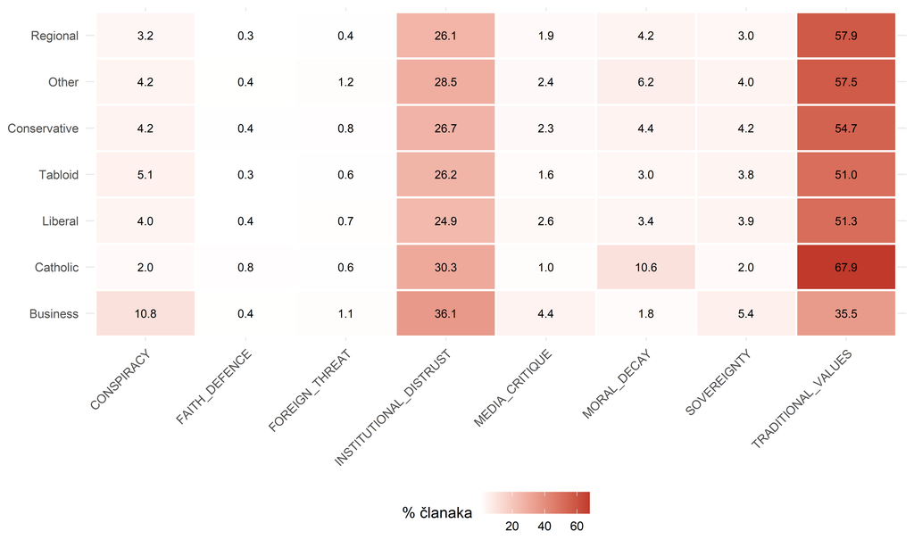

Figure 8: Slika 8. Toplinska karta narativnih profila po tipu medija (poredani po klasterima iz dendrograma)

```r
# Order media types by dendrogram
hc_order <- hc$labels[hc$order]

profile_long <- profile_data |>
  pivot_longer(cols = all_of(frame_cols), names_to = "frame", values_to = "pct") |>
  mutate(
    frame = str_remove(frame, "frame_"),
    media_type = factor(media_type, levels = hc_order)
  )

ggplot(profile_long, aes(x = frame, y = media_type, fill = pct)) +
  geom_tile(color = "white", linewidth = 0.8) +
  geom_text(aes(label = sprintf("%.1f", pct)), size = 3.2) +
  scale_fill_gradient(low = "white", high = "#c0392b", name = "% članaka") +
  labs(x = NULL, y = NULL) +
  theme(axis.text.x = element_text(angle = 45, hjust = 1))
```

Dendrogram i toplinska karta zajedno otkrivaju koji su medijski tipovi narativno “susjedni”. Ako se katolički mediji klasteriraju s konzervativnim medijima, to sugerira strukturnu sličnost narativnih strategija. Ako se klasteriraju zasebno, to ukazuje na specifičan narativni identitet.

### 4.3.3 Klasteriranje unutar katoličkog medijskog prostora

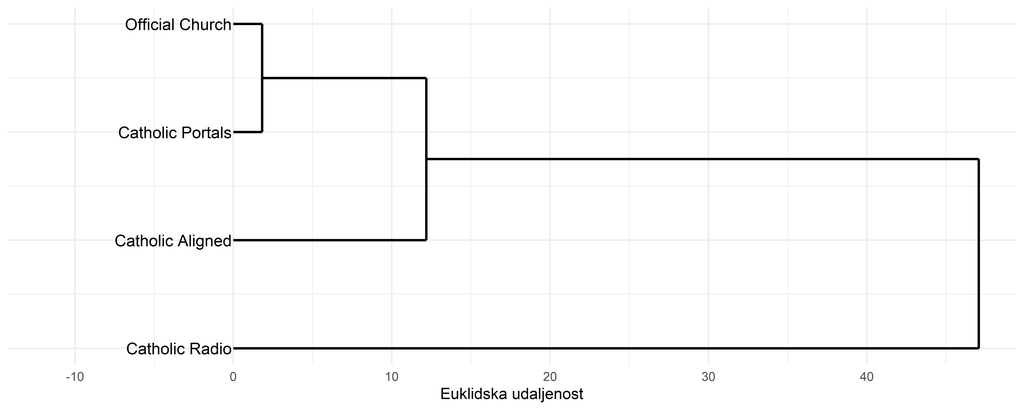

Figure 9: Slika 9. Dendrogram katoličkih potkategorija po narativnom profilu

```r
if (n_distinct(catholic_corpus$catholic_subcategory) > 2) {
  cath_profile <- catholic_corpus |>
    group_by(catholic_subcategory) |>
    summarise(across(all_of(frame_cols), ~mean(.x, na.rm = TRUE) * 100), .groups = "drop")

  cath_mat <- as.matrix(cath_profile |> select(-catholic_subcategory))
  rownames(cath_mat) <- cath_profile$catholic_subcategory

  cath_dist <- dist(cath_mat, method = "euclidean")
  cath_hc <- hclust(cath_dist, method = "ward.D2")

  cath_dend <- dendro_data(cath_hc)

  ggplot() +
    geom_segment(data = segment(cath_dend),
                 aes(x = x, y = y, xend = xend, yend = yend), linewidth = 0.8) +
    geom_text(data = label(cath_dend),
              aes(x = x, y = y, label = label),
              hjust = 1, size = 4, nudge_y = -0.1) +
    coord_flip() +
    scale_y_continuous(expand = expansion(mult = c(0.3, 0.05))) +
    labs(x = NULL, y = "Euklidska udaljenost") +
    theme_minimal() +
    theme(axis.text.y = element_blank(), axis.ticks.y = element_blank())
}
```

## 4.4 Analiza osjetljivosti na klasifikacijsku granicu (IP4)

Klasifikacija portala poput narod.hr i dnevno.hr kao “Catholic Aligned” jest istraživačka odluka. Ovi portali dijele određene narativne strategije i s konzervativnim medijima. Ova sekcija ispituje koliko rezultati ovise o toj odluci.

Provodimo dva scenarija:

- **Scenarij A** (osnovni): narod.hr, dnevno.hr, 7dnevno, direktno.hr, maxportal klasificirani kao Catholic Aligned
- **Scenarij B** (reklasifikacija): isti portali reklasificirani kao Conservative

```r
# Scenario B: reclassify Catholic Aligned as Conservative
aligned_outlets <- c("narod\\.hr", "dnevno\\.hr", "7dnevno", "direktno\\.hr", "maxportal")
aligned_pattern <- paste(aligned_outlets, collapse = "|")

corpus_scenB <- full_corpus |>
  mutate(
    media_type_B = case_when(
      catholic_subcategory == "Catholic Aligned" ~ "Conservative",
      TRUE ~ media_type
    ),
    catholic_subcategory_B = case_when(
      catholic_subcategory == "Catholic Aligned" ~ NA_character_,
      TRUE ~ catholic_subcategory
    )
  )
```

```r
# Scenario A
npi_A <- full_corpus |>
  group_by(media_type) |>
  summarise(mean_npi = round(mean(disinfo_alignment_norm, na.rm = TRUE), 2),
            N = n(), .groups = "drop") |>
  arrange(desc(mean_npi)) |>
  mutate(rank_A = row_number()) |>
  rename(media_A = media_type, npi_A = mean_npi, N_A = N)

# Scenario B
npi_B <- corpus_scenB |>
  group_by(media_type_B) |>
  summarise(mean_npi = round(mean(disinfo_alignment_norm, na.rm = TRUE), 2),
            N = n(), .groups = "drop") |>
  arrange(desc(mean_npi)) |>
  mutate(rank_B = row_number()) |>
  rename(media_B = media_type_B, npi_B = mean_npi, N_B = N)

# Display side by side
sensitivity_tbl <- bind_cols(
  npi_A |> select(media_A, N_A, npi_A, rank_A),
  npi_B |> select(media_B, N_B, npi_B, rank_B)
)

kable(sensitivity_tbl,
      col.names = c("Medij (A)", "N (A)", "NPI (A)", "Rang (A)",
                     "Medij (B)", "N (B)", "NPI (B)", "Rang (B)")) |>
  kable_styling(bootstrap_options = c("striped", "hover"), full_width = FALSE)
```

Table 6: Tablica 6. NPI po tipu medija: Scenarij A (osnovna klasifikacija) vs. Scenarij B (Catholic Aligned reklasificirani kao Conservative)

| Medij (A) | N (A) | NPI (A) | Rang (A) | Medij (B) | N (B) | NPI (B) | Rang (B) |
| --- | --- | --- | --- | --- | --- | --- | --- |
| Business | 1196 | 13.63 | 1 | Business | 1196 | 13.63 | 1 |
| Other | 256216 | 9.21 | 2 | Conservative | 37093 | 9.96 | 2 |
| Conservative | 18516 | 8.68 | 3 | Other | 256216 | 9.21 | 3 |
| Tabloid | 20720 | 8.67 | 4 | Tabloid | 20720 | 8.67 | 4 |
| Catholic | 92915 | 8.56 | 5 | Liberal | 28160 | 8.17 | 5 |
| Liberal | 28160 | 8.17 | 6 | Regional | 25415 | 8.02 | 6 |
| Regional | 25415 | 8.02 | 7 | Catholic | 74338 | 7.89 | 7 |

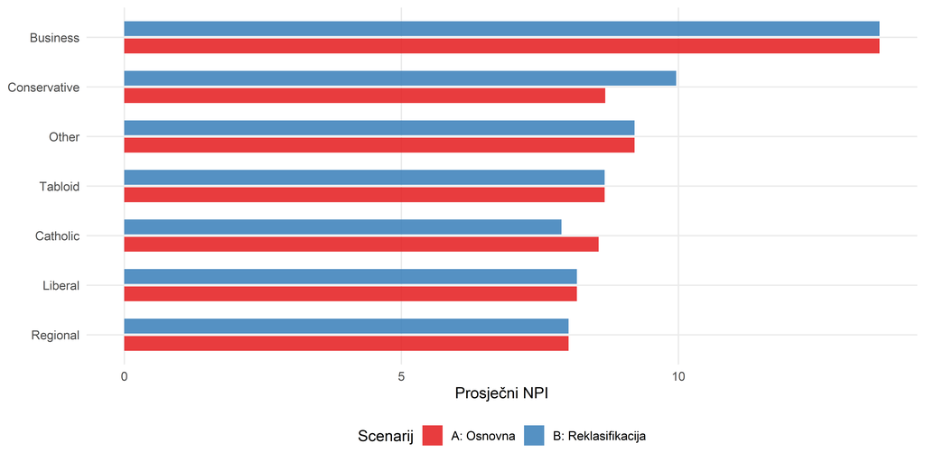

```r
compare_plot_data <- bind_rows(
  npi_A |> select(media = media_A, npi = npi_A) |> mutate(scenario = "A: Osnovna"),
  npi_B |> select(media = media_B, npi = npi_B) |> mutate(scenario = "B: Reklasifikacija")
)

ggplot(compare_plot_data, aes(x = reorder(media, npi), y = npi, fill = scenario)) +
  geom_col(position = position_dodge(width = 0.7), alpha = 0.85, width = 0.6) +
  coord_flip() +
  scale_fill_manual(values = c("A: Osnovna" = "#e41a1c", "B: Reklasifikacija" = "#377eb8")) +
  labs(x = NULL, y = "Prosječni NPI", fill = "Scenarij")
```

```r
# How many articles move
n_aligned <- sum(full_corpus$catholic_subcategory == "Catholic Aligned", na.rm = TRUE)
n_cath_total <- nrow(catholic_corpus)

cat("Analiza osjetljivosti: broj reklasificiranih članaka\n")
```

```
Analiza osjetljivosti: broj reklasificiranih članaka
```

```r
cat("=====================================================\n")
cat("Catholic Aligned članaka:", format(n_aligned, big.mark = ","), "\n")
```

```
Catholic Aligned članaka: 18,577
```

```r
cat("Ukupno katoličkih:", format(n_cath_total, big.mark = ","), "\n")
```

```
Ukupno katoličkih: 92,915
```

```r
cat("Udio koji se premješta:", round(n_aligned / n_cath_total * 100, 1), "%\n")
```

```
Udio koji se premješta: 20 %
```

Ako reklasifikacija Catholic Aligned portala značajno mijenja rang i prosječni NPI katoličke kategorije, to znači da su rezultati za kategoriju “Catholic” uvelike determinirani jednom potkategorijom čija je pripadnost sporna. Ovo je metodološki važan nalaz jer upozorava na potrebu za transparentnošću u klasifikacijskim odlukama.

## 4.5 NPI kroz vrijeme

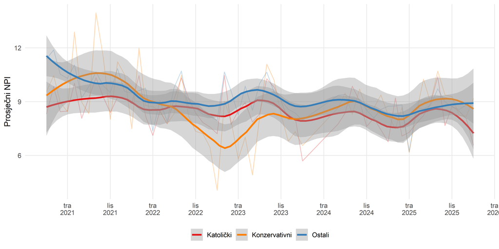

Figure 11: Slika 11. Prosječni NPI kroz vrijeme za katoličke medije, konzervativne medije i sve ostale

```r
npi_ts <- full_corpus |>
  mutate(
    group = case_when(
      media_type == "Catholic"     ~ "Katolički",
      media_type == "Conservative" ~ "Konzervativni",
      TRUE                         ~ "Ostali"
    )
  ) |>
  group_by(year_month, group) |>
  summarise(mean_npi = mean(disinfo_alignment_norm, na.rm = TRUE), .groups = "drop") |>
  filter(!is.na(year_month))

ggplot(npi_ts, aes(x = year_month, y = mean_npi, color = group)) +
  geom_line(alpha = 0.3) +
  geom_smooth(method = "loess", se = TRUE, linewidth = 1.2, span = 0.3) +
  scale_color_manual(values = c("Katolički" = "#e41a1c", "Konzervativni" = "#ff7f00",
                                 "Ostali" = "#377eb8")) +
  scale_x_date(date_breaks = "6 months", date_labels = "%b\n%Y") +
  labs(x = NULL, y = "Prosječni NPI", color = NULL)
```

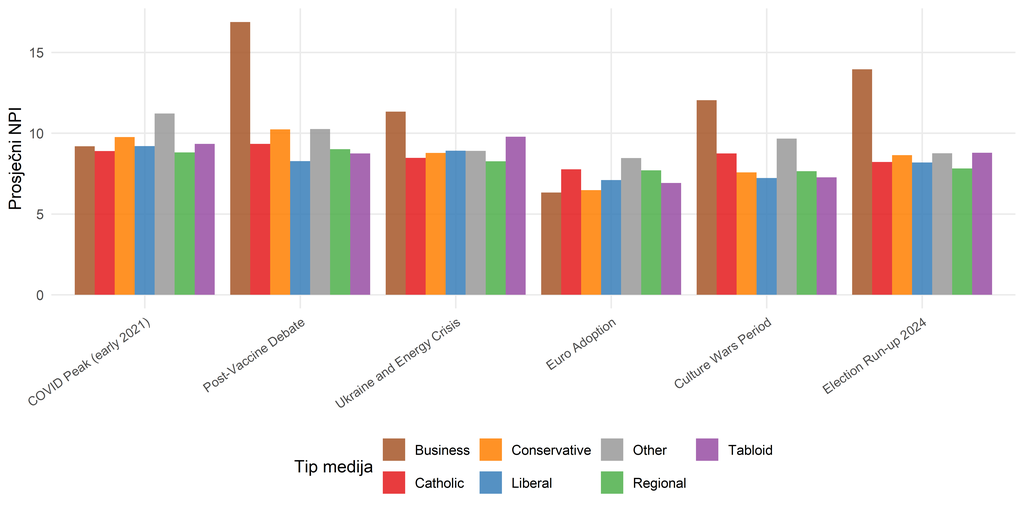

Figure 12: Slika 12. NPI po narativnoj fazi i tipu medija

```r
npi_phase <- full_corpus |>
  filter(!is.na(narrative_phase)) |>
  group_by(narrative_phase, media_type) |>
  summarise(mean_npi = mean(disinfo_alignment_norm, na.rm = TRUE), .groups = "drop")

ggplot(npi_phase, aes(x = narrative_phase, y = mean_npi, fill = media_type)) +
  geom_col(position = "dodge", alpha = 0.85) +
  scale_fill_manual(values = media_colors) +
  labs(x = NULL, y = "Prosječni NPI", fill = "Tip medija") +
  theme(axis.text.x = element_text(angle = 35, hjust = 1, size = 9))
```

# 5 Diskusija

Rezultati ovog istraživanja daju nekoliko doprinosa razumijevanju strukturne bliskosti medijskih narativa s dezinformacijskim ekosustavu.

**NPI razlikuje tipove medija (IP1).** Kompozitni indeks otkriva statistički značajne razlike u strukturnoj bliskosti s dezinformacijskim narativima. No interpretacija ovih razlika zahtijeva dva važna upozorenja. Prvo, NPI mjeri narativnu strukturu, ne istinitost. Članak s visokim NPI može sadržavati isključivo točne tvrdnje. Drugo, okviri koji ulaze u NPI (CONSPIRACY, FOREIGN_THREAT, INSTITUTIONAL_DISTRUST, MEDIA_CRITIQUE) imaju legitimne uporabe u demokratskom diskursu. Kritika institucija nije per se dezinformacijska. Ono što NPI hvata jest stupanj u kojem se ovi okviri koncentriraju i kombiniraju u pojedinim medijima.

**Robusnost rezultata (IP2).** Analiza s pet alternativnih specifikacija težina pokazuje stupanj u kojem je rangiranje medijskih tipova stabilno. Korelacijska matrica rangova kvantificira slaganje. Visoke korelacije znače da je rangiranje invarijantno na specifičan odabir težina, što daje povjerenje u nalaze. Niske korelacije za specifičnu specifikaciju identificiraju koje težinske odluke su analitički najutjecajnije.

**Narativni klasteri (IP3).** Hijerarhijsko klasteriranje otkriva strukturu hrvatskog medijskog prostora temeljena isključivo na narativnim profilima, bez a priori klasifikacije. Ova analiza je komplementarna klasifikaciji jer testira njenu unutarnju konzistentnost: ako se mediji koje smo klasificirali kao “Catholic” klasteriraju s medijima klasificiranim kao “Conservative”, to sugerira narativnu sličnost koja transcendira formalne kategorije.

**Osjetljivost na klasifikacijsku granicu (IP4).** Ovo je možda najvažniji metodološki nalaz. Analiza osjetljivosti pokazuje kako klasifikacijska odluka o pripadnosti Catholic Aligned portala utječe na ukupne rezultate za katoličku kategoriju. Ovo upozorava na potrebu za transparentnošću u istraživačkim odlukama o klasifikaciji medija, koja se u literaturi često tretira kao neproblematična.

## 5.1 Ograničenja

Kompozitni indeks inherentno reducira višedimenzionalan fenomen na jednodimenzionalnu mjeru. Unatoč analizi robusnosti, odabir okvira koji ulaze u indeks (a ne samo njihove težine) jest analitička odluka koja se može osporiti. Rječnička metoda detekcije ne prepoznaje kontekst ni ironiju. Analiza pokriva samo web članke iz jedne zemlje u ograničenom razdoblju i ne dopušta generalizacije na druge kontekste. NPI nije validiran na eksternom kriteriju (poput ekspertskog rangiranja medija po bliskosti dezinformacijskom ekosustavu), što ostaje zadatak za buduća istraživanja.

# 6 Zaključak

```r
cat("KLJUČNI NALAZI\n")
```

```
KLJUČNI NALAZI
```

```r
cat("==============\n\n")
cat("IP1: NPI otkriva statistički značajne razlike među medijskim tipovima\n")
```

```
IP1: NPI otkriva statistički značajne razlike među medijskim tipovima
```

```r
cat("IP2: Rangiranje je testirano na", length(specs), "alternativnih specifikacija\n")
```

```
IP2: Rangiranje je testirano na 5 alternativnih specifikacija
```

```r
cat("IP3: Klasteriranje identificira narativne blokove u medijskom prostoru\n")
```

```
IP3: Klasteriranje identificira narativne blokove u medijskom prostoru
```

```r
cat("IP4: Reklasifikacija Catholic Aligned portala kvantitativno mijenja rezultate\n")
```

```
IP4: Reklasifikacija Catholic Aligned portala kvantitativno mijenja rezultate
```

# 7 Tehničke informacije

## Reference

Bastos, Marco, and Marc Tuters. 2023. “Disinformation as Narrative Ecosystem.” *New Media and Society*.

Wardle, Claire, and Hossein Derakhshan. 2017. “Information Disorder: Toward an Interdisciplinary Framework for Research and Policy Making.” *Council of Europe Report*.

Wodak, Ruth. 2015. *The Politics of Fear: What Right-Wing Populist Discourses Mean*. Sage.